# Esercizio 1 - Regressione Lineare Semplice

Inserite il vostro nome

02 February 2023

# SLR - Esercizio

Si prenda in esame il dataset `bodyfat`:

```r
urlLocation <- "https://dasl.datadescription.com/download/data/3079"
bodyfat <- read.table(urlLocation, header=TRUE)
```

Il dataset (che è stato recuperato dal sito https://dasl.datadescription.com/datafile/bodyfat/) comprende molte variabili: per il momento prendiamo in considerazione sono le variabili `Weight` e `Height`, che contengono i valori di peso (misurato in libbre) e altezza (misurata in pollici) per 250 uomini di varie età. In particolare vogliamo valutare come l’altezza influenzi il peso.

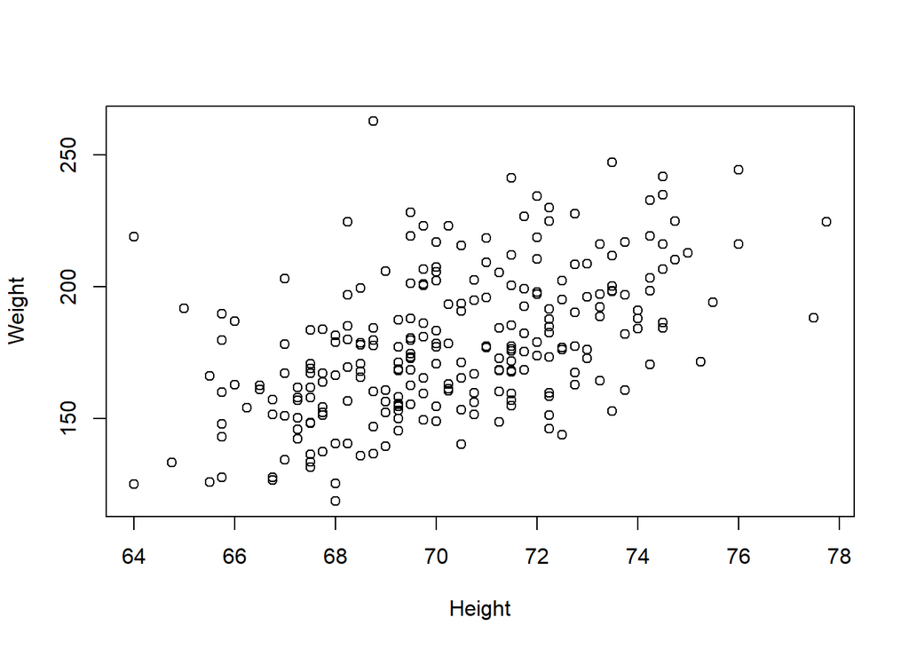

```r
bodyfat <- bodyfat[,c("Weight","Height")]
plot(Weight~Height, data = bodyfat)
```

## Esercizio 1

Si dia una stima del modello: valori dei coefficienti e loro significatività. Si interpreti il valore di ognuno dei coefficienti.

Il modello stimato e’ il seguente:

$$\mathbb{E}[Y|X=x] = \beta_{0} +
\beta_{1}x$$
Che e’ equivalente al modello

$$Weight = \beta_{0} +
\beta_{1}Height$$

```r
fit <- lm(Weight~Height, data = bodyfat)
summary(fit)
```

```
##
## Call:
## lm(formula = Weight ~ Height, data = bodyfat)
##
## Residuals:
##     Min      1Q  Median      3Q     Max
## -47.378 -16.032  -1.465  13.816  92.897
##
## Coefficients:
##              Estimate Std. Error t value Pr(>|t|)
## (Intercept) -194.4861    39.6230  -4.908 1.67e-06 ***
## Height         5.2995     0.5632   9.409  < 2e-16 ***
## ---
## Signif. codes:  0 '***' 0.001 '**' 0.01 '*' 0.05 '.' 0.1 ' ' 1
##
## Residual standard error: 23.26 on 248 degrees of freedom
## Multiple R-squared:  0.2631, Adjusted R-squared:  0.2601
## F-statistic: 88.54 on 1 and 248 DF,  p-value: < 2.2e-16
```

Il modello stimato e’ significativo, e cio’ viene corroborato dai seguenti aspetti:

- La stima di $\beta_{0}$, ovvero dell’interecetta, e’ di -194.4861343. Il parametro stimato e’ molto significativo dal momento che si nota un valore assoluto del `t value` molto alto con un relativo `p value` particolarmente significativo nella tabella prodotta dal `summary`. Percio’ possiamo rifiutare l’ipotesi nulla $H_{0}: \beta_{0} = 0$. E’ giusto menzionare pero’ che l’incertezza relativa alla stima sembri essere particolarmente alta.
  - Il valore dell’intercetta viene interpretato come $\beta_{0} = \mathbb{E}[Y|X=0]$. Il parametro che costringe la regressione a passare per il punto (0, -194.4861343).
- La stima di $\beta_{1}$, ovvero del coefficiente angolare, e’ di 5.2994799. Il parametro stimato e’ molto significativo dal momento che si nota un valore assoluto del `t value` molto alto con un relativo `p value` particolarmente significativo nella tabella prodotta dal `summary`. Percio’ possiamo rifiutare l’ipotesi nulla $H_{0}: \beta_{1} = 0 \rightarrow \mathbb{E}[Y|X=x]=\beta_{0}$. E’ giusto menzionare che l’incertezza relativa alla stima sia abbastanza bassa.
  - Il valore del coefficiente angolare viene interpretato come segue: La differenza in peso (espresso in libbre), tra due uomini la cui altezza varia di un pollice, e’ in media di 5.2994799 libbre.

## Esercizio 2

Qual è il valore del coefficiente $R^2$ - come si può interpretare questo valore?

Il valore di $R^2$ e’ di 0.2630798, il quale indica che circa un 26 percento della varianza totale dei dati e’ spiegata dalla relazione lineare tra `Height` e `Weight`.

## Esercizio 3

Vi è evidenza della veridicità dell’affermazione: “Due uomini la cui altezza differisca di un pollice hanno in media una differenza di peso di 5 libbre”?

Vogliamo verificare se sia possibile falsificare l’affermazione “Due uomini la cui altezza differisca di un pollice hanno in media una differenza di peso di 5 libbre”. Questo corrisponde a falsificare l’affermazione $\beta_1 = 5$, cioè a testare il sistema di ipotesi:

$$H_{0}: \beta_{1} = 5 \mbox{ vs } H_{A}:
\beta_{1} \neq 5$$
Per fare cio’ calcoliamo la statistica test

$$TS =
\frac{\hat{\beta_{1}}-HYP}{SE[\hat{\beta_{1}}]} =
\frac{0.2994799}{0.5632146}$$

```r
# tobs = (est - hyp)/ se[bj]
t_obs <- (summary(fit)$coef[2,1]-5)/summary(fit)$coeff[2,2]

2*pt(abs(t_obs),df=nrow(bodyfat)-2, lower.tail = FALSE)
```

```
## [1] 0.5953868
```

Dal momento che TS, non ha un valore grande e che il p-value 0.5953868 e’ poco significativo, ad un livello di significativita’ del 5%, non si puo’ rifiutare l’ipotesi nulla che due uomini la cui altezza differisca di un pollice hanno in media una differenza di peso di 5 libbre.

## Esercizio 4

Si diano un intervallo di confidenza e di predizione al 90% per due nuovi soggetti di altezza 70 e 78 pollici. Si dia un commento sull’ampiezza dei due intervalli di confidenza.

```r
nd <- data.frame(Height = c(70, 78))

conf <- predict(fit, newdata = nd, interval="confidence", level=0.9)
c("Intervalli di Confidenza", conf[1,3]-conf[1,2], conf[2,3]-conf[2,2])
```

```
## [1] "Intervalli di Confidenza" "4.8891660600936"
## [3] "15.1159850727846"
```

```r
pred <-predict(fit, newdata = nd, interval="prediction", level=0.9)
c("Intervalli di Predizione", pred[1,3]-pred[1,2], pred[2,3]-pred[2,2])
```

```
## [1] "Intervalli di Predizione" "76.9448190192676"
## [3] "78.2629812482589"
```

Di norma, gli intervalli di confidenza tendono ad essere sempre piu’ stretti rispetto agli intervalli di predizione dal momento che si deve aggiungere ulteriore incertezza alla stima.

In questo caso, gli intervalli sono costruiti rispetto a due ipotetici uomini che hanno rispettivamente un’ altezza di 70 pollici (vicino alla media 70.303) ed un’ altezza di 78, piuttosto estrema sebbene gia’ osservata nei dati.

Dato che la retta stimata passa necessariamente per il punto $(\bar{x}, \bar{y})$ vi è meno incertezza nella stima del valore di $Y|X=x_0$ quando $x_0$ è vicino a $\bar{x}$. Per questo motivo l’intervallo di confidenza per il primo risulta essere stretto, mentre peril secondo si nota il risultato del fatto che il campione abbia poche osservazioni per uomini di 78 pollici.

Nell’intervallo di predizione invece la differenza tra la grandezza dei due intervalli non e’ poi cosi’ grande, sebbene l’introduzione di maggior variabilita’ risulti in due intervalli molto ampi.

## Esercizio 5

Si elenchino le assunzioni fatte per poter stimare il modello. Si usino dei grafici utili ad investigare se le assunzioni risultano essere valide per il modello stimato.

Le assunzioni si possono scrivere in maniera sintetica come $Y_i|X=x_i \stackrel{iid}{\sim} N(\beta_0 + \beta_1 x_i, \sigma)$ per ogni $i= 1, \ldots, n$.

Si deve quindi verificare che la relazione tra X ed Y sia costante e che le osservazioni seguano una normale a varianza costante.

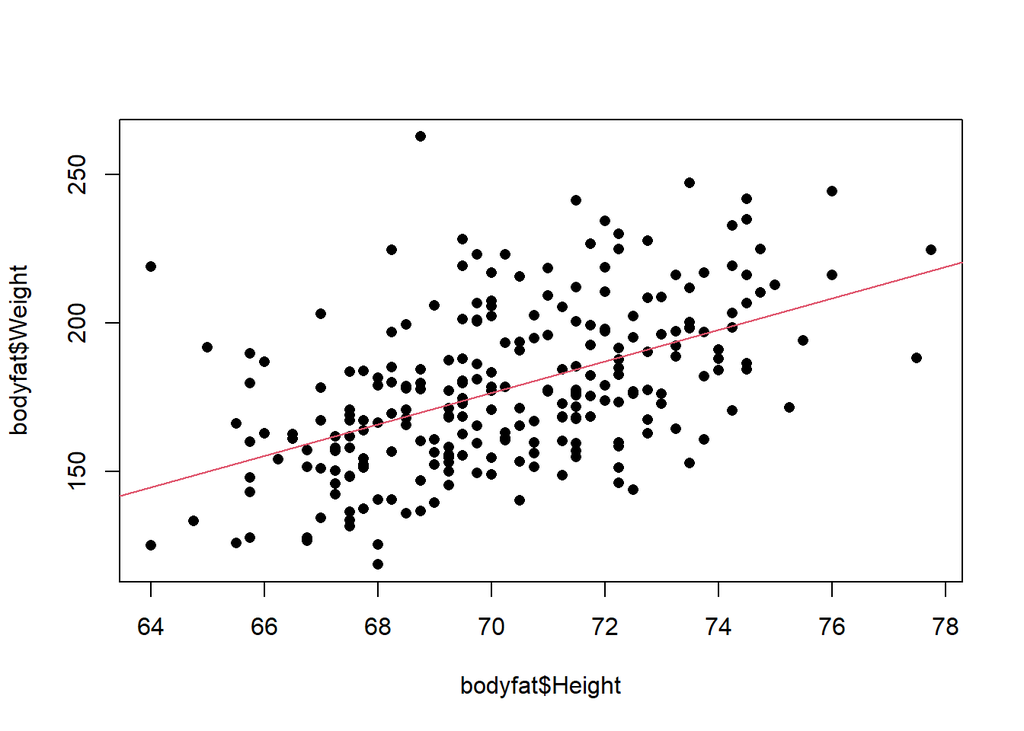

```r
plot(bodyfat$Weight~bodyfat$Height, pch=16)
abline(fit$coefficients[1], fit$coefficients[2], col=2)
```

Dal momento che il dataset si limita a due colonne, di cui una rappresenta il predittore e l’altra il target, non ci e’ possibile verificare se altri predittori possano essere rilevanti per il modello.

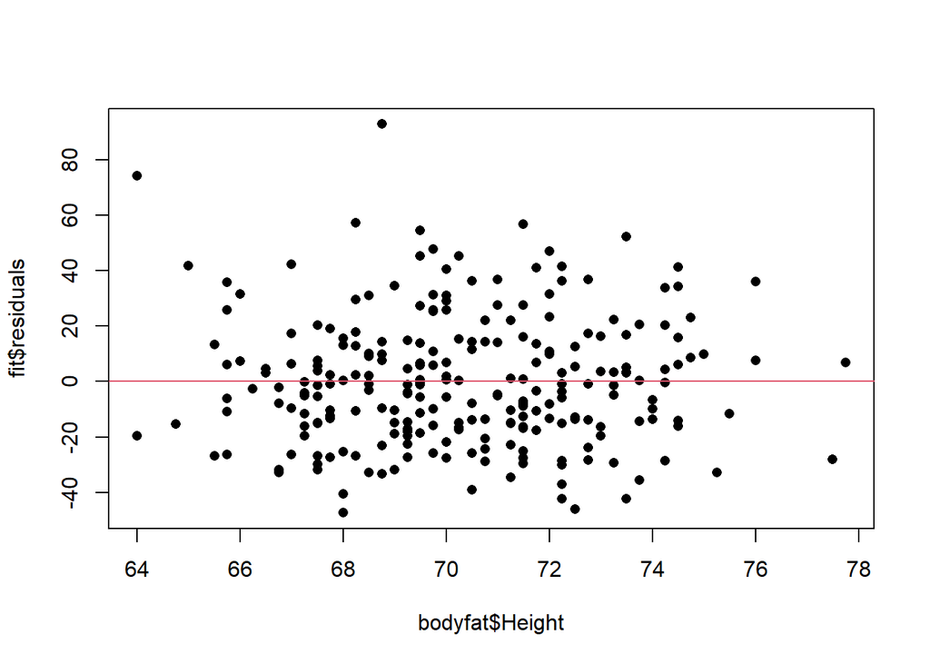

```r
plot(fit$residuals~bodyfat$Height, pch=16)
abline(h=0, col=2)
```

Dal grafico tra la variabile predittore e i residui non emerge nessuna forte indicazione di una qualche forma relazionale tra `Height` e `Weight` non spiegata dal modello lineare.

Per quello che riguarda la normalita’, nel grafico precedente notiamo valori alti per alcuni residui. Questi sono visibili anche tramite il qqplot che aiuta a verificare proprio la normalita’ dei residui.

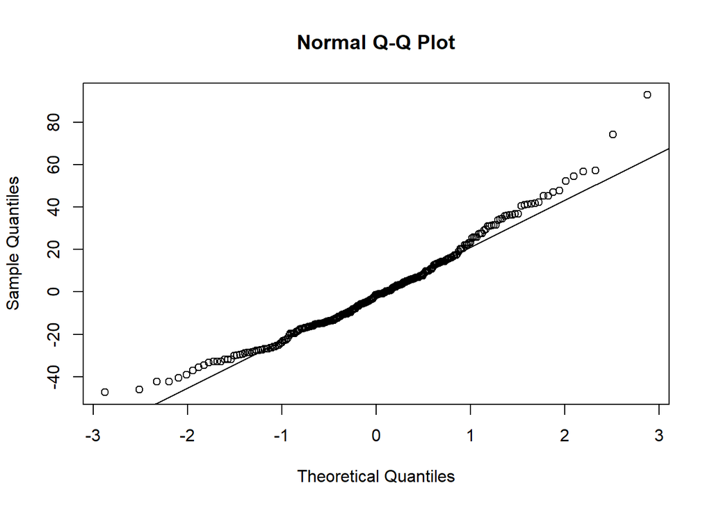

```r
qqnorm(resid(fit))
qqline(resid(fit))
```

Sebbene si notino i valori alti e una leggera curvatura dei punti, il qqplot risulta abbastanza soddisfacente e i residui sembrano comportarsi come un campione di una normale.

Infine, il grafico di valori stimati contro residui è spesso utile per controllare l’assunzione di varianza costante:

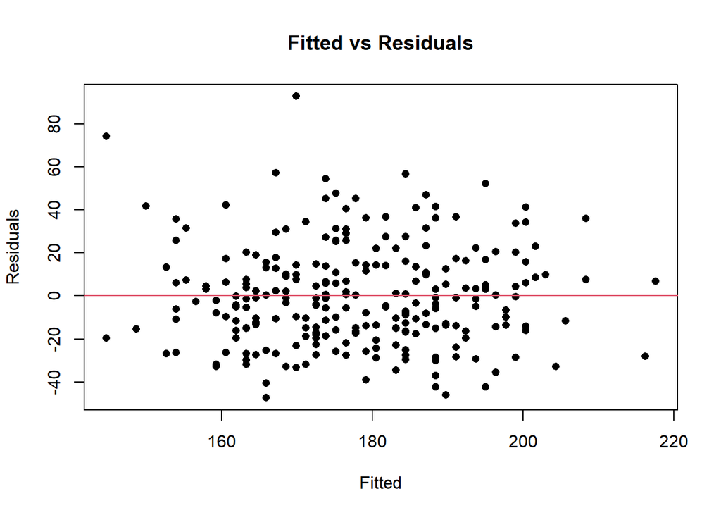

```r
plot(fit$residuals~fitted.values(fit), pch=16, xlab="Fitted", ylab="Residuals",
     main = "Fitted vs Residuals")
abline(a=0, b=0, col=2)
```

Dal grafico, vediamo che i residui sono incentrati attorno alla media 0, ed hanno una varianza costante. Possiamo quindi confermare che gli errori siano omoschedastici.

Verificare che le osservazioni siano indipendenti è complicato in questo caso: non abbiamo un test per farlo. Possiamo sperare che lo schema di campionamento usato abbia evitato per esempio di inserire persone della stessa famiglia (fratelli, cugini, etc…) o non abbiano selezionato molti giocatori di basket professionisti (alti e probabilmente con una costituzione corporea diversa da quella della popolazione generale). Con le informazioni disponibili possiamo sperare che il campione sia composto da osservazioni indipendenti e rappresentative della popolazione generale.

## Esercizio 6 - Extra

Qual è l’interpretazione dell’intercetta nel modello? Cosa succede se si stima un modello usando una nuova variabile `HeightCentred = Height - mean(Height)`.

L’intercetta del modello e’ riscrivibile come $\beta_{0} = \mathbb{E}[Y|X=0]$, percio’ la regressione passa per il punto (0, -194.4861343). Dal momento che non vi persone alte 0 pollici, la sua interpretazione e’ poco utile.

```r
bodyfat$HeightCentred <- bodyfat$Height - mean(bodyfat$Height)

fit2 <- lm(Weight~HeightCentred, data = bodyfat)

summary(fit2)
```

```
##
## Call:
## lm(formula = Weight ~ HeightCentred, data = bodyfat)
##
## Residuals:
##     Min      1Q  Median      3Q     Max
## -47.378 -16.032  -1.465  13.816  92.897
##
## Coefficients:
##               Estimate Std. Error t value Pr(>|t|)
## (Intercept)   178.0832     1.4708 121.081   <2e-16 ***
## HeightCentred   5.2995     0.5632   9.409   <2e-16 ***
## ---
## Signif. codes:  0 '***' 0.001 '**' 0.01 '*' 0.05 '.' 0.1 ' ' 1
##
## Residual standard error: 23.26 on 248 degrees of freedom
## Multiple R-squared:  0.2631, Adjusted R-squared:  0.2601
## F-statistic: 88.54 on 1 and 248 DF,  p-value: < 2.2e-16
```

```r
colMeans(bodyfat)
```

```
##        Weight        Height HeightCentred
##  1.780832e+02  7.030300e+01  2.728484e-15
```

Stimando un modello con una nuova variabile `HeightCentred = Height - mean(Height)`, l’intercetta diventa $\beta_{0} = \mathbb{E}[Y|X =\bar{x} = 0] = \bar{y}$, facendo passare la regressione per il punto $(\mathbb{E}[X]=0,\mathbb{E}[Y])$ = (0, 178.0832).

## Esercizio 7 - Extra

Si creino le variabili `HightScale = (Height - mean(Height))/sd(Height)` e `WeightScale = (Weight - mean(Weight))/sd(Weight)`. Come si possono interpretare intercetta a coefficiente angolare per questo modello? Si confronti il valore di $R^2$ e il p-value del test di significatività per $\beta_1$ nel modello stimato usando i dati modificati e i dati originali: cosa si può notare? [Per creare le nuove variabili si può anche usare direttamente la funzione `scale`.]

## Esercizio 8 - Extra

Le variabili sono state misurate rispettivamente in pollici e libbre. Si trasformino i dati in centimetri e chilogrammi: come cambiano le stime dei parametri del modello lineare? Come cambia la loro interpretazione? [Nota: per passare da pollici a cm è necessario moltiplicare i valori originali per 2.54; per passare da libbre a chilogrammi è necessario dividere i valori originali per 2.205].

## Esercizio 9 - Extra

Quale potrebbe essere l’intervallo di confidenza del peso di una donna alta 72 pollici?

## Esercizio 10 - Extra

- Si estragga (usando in maniera appropriata la funzione `sample`) un sottocampione del dataset di 50 osservazioni: si confrontino le stime ottenute usando tutto il campione e le stime ottenute usando il sottocampione.